# EDA for P1

Addison McGhee

2021-12-08

### Load data from .csv files saved in Data folder

```r
injuries = read.csv("../../Data/data_for_plots/Q1/injury_dat_q1.csv", stringsAsFactors = T) %>%
  mutate(injury = factor(injury))

players = read.csv("../../Data/data_for_plots/Q1/players_dat_q1.csv", stringsAsFactors = T) %>% mutate(injury = factor(injury))
```

# P1

### Q1: Which positions are most at-risk for injuries? The table below contains descriptive statistics calculated for each position over multiple seasons (2009 - Present).

```r
# set up table
number_injury = injuries %>%
  group_by(position_id, year) %>%
  count()

number_injury %>% group_by(position_id) %>%
  summarise(mean = mean(n),
            sd = sd(n),
            Q1 = quantile(n, probs = 0.25),
            median = median(n),
            Q3 = quantile(n, probs = 0.75)
  ) %>%
  pander
```

| position_id | mean | sd | Q1 | median | Q3 |
| --- | --- | --- | --- | --- | --- |
| DEF | 511.8 | 130.1 | 413 | 603 | 617 |
| K | 10.38 | 5.009 | 10 | 11 | 12 |
| OL | 192.6 | 40.31 | 180 | 199 | 210 |
| P | 6.769 | 3.7 | 4 | 8 | 10 |
| QB | 32.69 | 12.01 | 24 | 36 | 41 |
| RB | 95.69 | 24.68 | 81 | 107 | 115 |
| TE | 66.85 | 15.79 | 62 | 69 | 77 |
| WR | 130.3 | 25.03 | 116 | 131 | 149 |

This table does not account for the number of people who play each position. Let’s make a new table that may be more useful.

### avg. # of injuries per position per season, among people who get injured

```r
# (meaning if I am a wide receiver, how many injuries can I expect to get this season?)

# total injuries per player per year
exp_injuries <- players %>%
  filter(!is.na(total_injuries)) %>% # remove players with no injury (NA's)
  group_by(position_id) %>%
  summarise(avg_total_injuries = sum(total_injuries)/n(),
            SD = sd(total_injuries),
            Q1 = quantile(total_injuries, probs = 0.25),
            Median = median(total_injuries),
            Q3 = quantile(total_injuries, probs = 0.75),
            Min = min(total_injuries),
            Max = max(total_injuries)
  )

exp_injuries %>% pander
```

| position_id | avg_total_injuries | SD | Q1 | Median | Q3 | Min | Max |
| --- | --- | --- | --- | --- | --- | --- | --- |
| DEF | 1.643 | 1.035 | 1 | 1 | 2 | 1 | 16 |
| K | 1.17 | 0.3774 | 1 | 1 | 1 | 1 | 2 |
| OL | 1.565 | 0.9145 | 1 | 1 | 2 | 1 | 9 |
| P | 1.205 | 0.4589 | 1 | 1 | 1 | 1 | 3 |
| QB | 1.689 | 1.405 | 1 | 1 | 2 | 1 | 21 |
| RB | 1.711 | 1.107 | 1 | 1 | 2 | 1 | 10 |
| TE | 1.623 | 1.031 | 1 | 1 | 2 | 1 | 13 |
| WR | 1.697 | 1.042 | 1 | 1 | 2 | 1 | 9 |

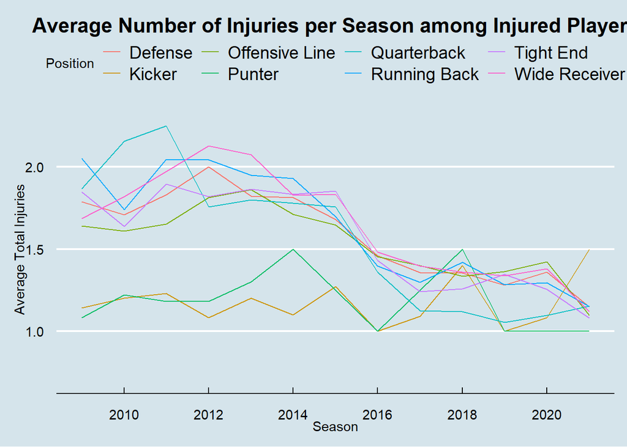

```r
# code for plot over time
exp_injuries_byYear <- players %>%
  filter(!is.na(total_injuries)) %>% # remove players with no injury (NA's)
  group_by(position_id, year) %>%
  summarise(avg_total_injuries = sum(total_injuries)/n())# trying to divide by number of players to get avg. for each player
# plot
exp_injuries_byYear %>%
  ggplot(aes(x = year, y = avg_total_injuries, color = position_id)) +
  geom_line() +
  ggtitle("Average Number of Injuries per Season among Injured Players") +
  ylim(0.7, 2.3) +
  xlab("Season") +
  ylab("Average Total Injuries") +
  scale_x_continuous(breaks = seq(2008, 2020, by = 2)) +
  scale_color_discrete(name = "Position", labels = c("Defense", "Kicker", "Offensive Line", "Punter",
                                                     "Quarterback", "Running Back", "Tight End", "Wide Receiver"))
```

Note: we can’t include people who were not injured in this calculation, because we have a complete dataset of injured players, but we do not have a complete dataset of non-injured players.

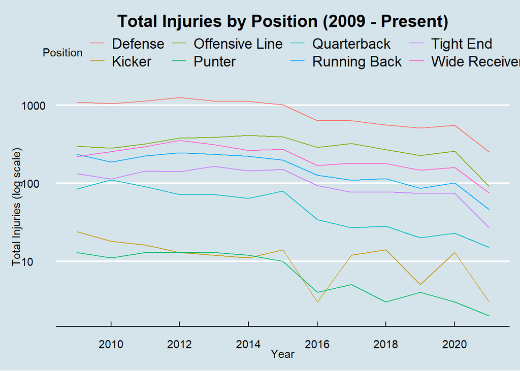

```r
players %>% group_by(position_id, year) %>%
  summarise(total = sum(total_injuries, na.rm = T)) %>%
  ggplot(aes(year, total, color = position_id)) +
  geom_line() +
  xlab("Year") +
  ylab("Total Injuries (log scale)") +
  scale_color_discrete(name = "Position") +
  scale_y_log10() +
  ggtitle("Total Injuries by Position (2009 - Present)") +
  scale_x_continuous(breaks = seq(2008, 2020, by = 2)) +
  scale_color_discrete(name = "Position", labels = c("Defense", "Kicker", "Offensive Line", "Punter",
                                                     "Quarterback", "Running Back", "Tight End", "Wide Receiver"))
```

### We now will switch to our second analysis (Machine Learning)

- We will perform logistic regression, kNN, and random forest using the binary outcome `injury`.
- We will then compare the results of the different methods based on accuracy, sensitivity/specificity, and ROC/AUC.
- Logical potential predictors: position_id, height_inches, weight_pounds, game_starter, age, bmi

### Our first step is to check for missing data in our predictors and outcome

```r
apply(players %>%
        dplyr::select(injury, position_id, height_inches, weight_pounds, game_starter, age, bmi, year),
      2, function(x) sum(is.na(x))) %>% pander
```

Table continues below

| injury | position_id | height_inches | weight_pounds | game_starter | age |
| --- | --- | --- | --- | --- | --- |
| 0 | 0 | 13 | 11 | 0 | 0 |

| bmi | year |
| --- | --- |
| 13 | 0 |

```r
# remove the 13 people with missing height/weight (much less than 5% of each column)
players <- players %>%
  drop_na(height_inches)
```

### What is the distribution of BMI for the injured vs non-injured players?

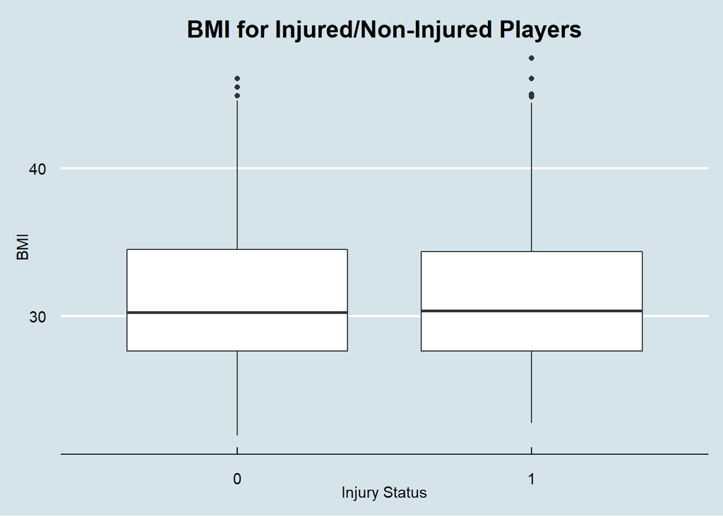

```r
players %>% ggplot(aes(injury, bmi)) +
              geom_boxplot() +
              xlab("Injury Status") +
              ylab("BMI") +
              ggtitle("BMI for Injured/Non-Injured Players")
```

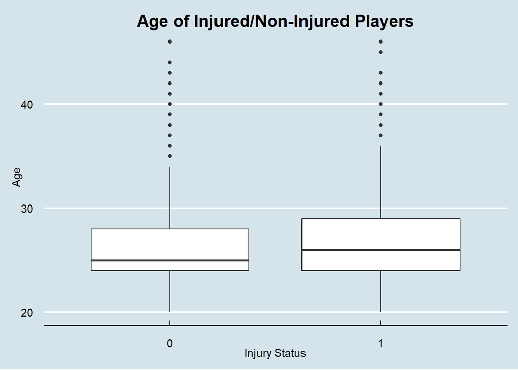

```r
players %>% ggplot(aes(injury, age)) +
              geom_boxplot() +
              xlab("Injury Status") +
              ylab("Age") +
              ggtitle("Age of Injured/Non-Injured Players")
```

**The absence of any significant difference between groups suggests that `bmi` will not be a significiant predictor in our Logistic model. However, the boxplots for `age` suggest the opposite, mainly that `age` may be a sigificant predictor.**

### Logistic regression (model only; check for significant coefficients)

```r
players = players %>% mutate(position_id = relevel(position_id, ref = "TE"))

logi_fit = glm(data = players, injury ~ position_id + bmi + age, family = binomial())
pander(summary(logi_fit))
```

|  | Estimate | Std. Error | z value | Pr(>\|z\|) |
| --- | --- | --- | --- | --- |
| **(Intercept)** | -1.327 | 0.1513 | -8.771 | 1.772e-18 |
| **position_idDEF** | 0.09225 | 0.05234 | 1.762 | 0.07799 |
| **position_idK** | -1.405 | 0.113 | -12.44 | 1.681e-35 |
| **position_idOL** | -0.08894 | 0.05979 | -1.488 | 0.1368 |
| **position_idP** | -1.712 | 0.1296 | -13.22 | 7.058e-40 |
| **position_idQB** | -0.4968 | 0.08206 | -6.054 | 1.412e-09 |
| **position_idRB** | 0.158 | 0.06474 | 2.441 | 0.01465 |
| **position_idWR** | 0.1636 | 0.06251 | 2.618 | 0.008854 |
| **bmi** | -0.005615 | 0.003509 | -1.6 | 0.1096 |
| **age** | 0.05918 | 0.003945 | 15 | 7.057e-51 |

(Dispersion parameter for binomial family taken to be 1 )

| Null deviance: | 36933 on 26649 degrees of freedom |
| --- | --- |
| Residual deviance: | 36230 on 26640 degrees of freedom |

### The older players could be skewing the results! The odds of getting injured for players above 40 is very high, mainly because there are very players who play at or above this age.

### Let’s remove the players above 40 y/o and see if `age` is still significant

```r
logi_fit2 = glm(data = players %>% filter(age < 40), injury ~ position_id + bmi + age, family = binomial())
pander(summary(logi_fit2))
```

|  | Estimate | Std. Error | z value | Pr(>\|z\|) |
| --- | --- | --- | --- | --- |
| **(Intercept)** | -1.341 | 0.1523 | -8.808 | 1.279e-18 |
| **position_idDEF** | 0.09261 | 0.05235 | 1.769 | 0.07687 |
| **position_idK** | -1.412 | 0.1157 | -12.2 | 2.965e-34 |
| **position_idOL** | -0.08962 | 0.0598 | -1.499 | 0.1339 |
| **position_idP** | -1.691 | 0.1301 | -13 | 1.286e-38 |
| **position_idQB** | -0.4936 | 0.08232 | -5.996 | 2.028e-09 |
| **position_idRB** | 0.1584 | 0.06475 | 2.447 | 0.0144 |
| **position_idWR** | 0.1642 | 0.06251 | 2.627 | 0.008616 |
| **bmi** | -0.00555 | 0.00351 | -1.581 | 0.1139 |
| **age** | 0.05966 | 0.004002 | 14.91 | 3.05e-50 |

(Dispersion parameter for binomial family taken to be 1 )

| Null deviance: | 36864 on 26600 degrees of freedom |
| --- | --- |
| Residual deviance: | 36165 on 26591 degrees of freedom |

### Let’s try Quadratic Age, too (may not be a linear relationship with injuries)

```r
players = players %>% mutate(age_sq = age^2)

logi_fit3 = glm(data = players %>% filter(age < 40), injury ~ position_id + bmi + age + age_sq, family = binomial())
pander(summary(logi_fit3))
```

|  | Estimate | Std. Error | z value | Pr(>\|z\|) |
| --- | --- | --- | --- | --- |
| **(Intercept)** | -3.995 | 0.6927 | -5.767 | 8.075e-09 |
| **position_idDEF** | 0.09295 | 0.05236 | 1.775 | 0.07585 |
| **position_idK** | -1.373 | 0.1157 | -11.87 | 1.797e-32 |
| **position_idOL** | -0.09093 | 0.0598 | -1.52 | 0.1284 |
| **position_idP** | -1.659 | 0.13 | -12.76 | 2.575e-37 |
| **position_idQB** | -0.4716 | 0.08238 | -5.724 | 1.04e-08 |
| **position_idRB** | 0.1603 | 0.06478 | 2.475 | 0.01332 |
| **position_idWR** | 0.1675 | 0.06254 | 2.679 | 0.007387 |
| **bmi** | -0.005738 | 0.003512 | -1.634 | 0.1023 |
| **age** | 0.2548 | 0.04984 | 5.112 | 3.189e-07 |
| **age_sq** | -0.003524 | 0.000897 | -3.929 | 8.525e-05 |

(Dispersion parameter for binomial family taken to be 1 )

| Null deviance: | 36864 on 26600 degrees of freedom |
| --- | --- |
| Residual deviance: | 36150 on 26590 degrees of freedom |

**age squared is significant**

# Machine Learning and Prediction

### Create training and test set

```r
set.seed(1)

x <- stratified(players, "injury", 0.7, keep.rownames = TRUE)
train_set <- x %>% dplyr::select(-rn)
train_index <- as.numeric(x$rn)
test_set <- players[-train_index,]

dim(train_set)
```

```
## [1] 18655    40
```

```r
dim(test_set)
```

```
## [1] 7995   40
```

#### NOTE: Accuracy improved after removing `bmi` as a predictor

### Logistic regression

#### Stepwise model selection to choose best covariates

```r
# baseline logistic regression model (intercept only)
logi_fit_all <- glm(data = players, injury ~ 1, family = binomial())
summary(logi_fit_all)
```

```
##
## Call:
## glm(formula = injury ~ 1, family = binomial(), data = players)
##
## Deviance Residuals:
##    Min      1Q  Median      3Q     Max
##  -1.20   -1.20    1.16    1.16    1.16
##
## Coefficients:
##             Estimate Std. Error z value Pr(>|z|)
## (Intercept)   0.0423     0.0123    3.45  0.00055 ***
## ---
## Signif. codes:  0 '***' 0.001 '**' 0.01 '*' 0.05 '.' 0.1 ' ' 1
##
## (Dispersion parameter for binomial family taken to be 1)
##
##     Null deviance: 36933  on 26649  degrees of freedom
## Residual deviance: 36933  on 26649  degrees of freedom
## AIC: 36935
##
## Number of Fisher Scoring iterations: 3
```

```r
# forward selection
logi_step_fit <- logi_fit_all %>%
  step(direction = "forward", data = players,
       scope = (~ position_id + height_inches + weight_pounds + game_starter +
                  age + I(age^2) + bmi + year))
```

```
## Start:  AIC=36935
## injury ~ 1
##
##                 Df Deviance   AIC
## + game_starter   1    35337 35341
## + year           1    35721 35725
## + position_id    7    36458 36474
## + age            1    36832 36836
## + I(age^2)       1    36845 36849
## + height_inches  1    36922 36926
## <none>                36933 36935
## + weight_pounds  1    36932 36936
## + bmi            1    36933 36937
##
## Step:  AIC=35341
## injury ~ game_starter
##
##                 Df Deviance   AIC
## + year           1    34089 34095
## + position_id    7    34919 34937
## + height_inches  1    35251 35257
## + weight_pounds  1    35275 35281
## + bmi            1    35304 35310
## + age            1    35309 35315
## + I(age^2)       1    35313 35319
## <none>                35337 35341
##
## Step:  AIC=34095
## injury ~ game_starter + year
##
##                 Df Deviance   AIC
## + position_id    7    33675 33695
## + height_inches  1    34011 34019
## + weight_pounds  1    34021 34029
## + bmi            1    34046 34054
## + age            1    34073 34081
## + I(age^2)       1    34076 34084
## <none>                34089 34095
##
## Step:  AIC=33695
```

[output cut: 22 more lines]

```
##
##                 Df Deviance   AIC
## + I(age^2)       1    33561 33587
## <none>                33566 33590
## + bmi            1    33565 33591
## + height_inches  1    33566 33592
##
## Step:  AIC=33587
## injury ~ game_starter + year + position_id + age + weight_pounds +
##     I(age^2)
##
##                 Df Deviance   AIC
## <none>                33561 33587
## + bmi            1    33560 33588
## + height_inches  1    33560 33588
```

```r
summary(logi_step_fit)
```

```
##
## Call:
## glm(formula = injury ~ game_starter + year + position_id + age +
##     weight_pounds + I(age^2), family = binomial(), data = players)
##
## Deviance Residuals:
##    Min      1Q  Median      3Q     Max
## -2.016  -1.074   0.613   1.056   2.243
##
## Coefficients:
##                 Estimate Std. Error z value Pr(>|z|)
## (Intercept)     2.46e+02   7.27e+00   33.86  < 2e-16 ***
## game_starter    1.03e+00   2.77e-02   37.36  < 2e-16 ***
## year           -1.23e-01   3.59e-03  -34.33  < 2e-16 ***
## position_idDEF  5.21e-02   5.54e-02    0.94   0.3471
## position_idK   -1.01e+00   1.18e-01   -8.54  < 2e-16 ***
## position_idOL  -1.48e-01   6.21e-02   -2.39   0.0170 *
## position_idP   -1.33e+00   1.33e-01  -10.00  < 2e-16 ***
## position_idQB  -7.61e-01   8.67e-02   -8.77  < 2e-16 ***
## position_idRB   1.90e-01   6.94e-02    2.75   0.0060 **
## position_idWR   1.30e-01   6.74e-02    1.94   0.0529 .
## age             1.45e-01   4.66e-02    3.10   0.0019 **
## weight_pounds  -2.22e-03   3.84e-04   -5.79  7.2e-09 ***
## I(age^2)       -1.92e-03   8.33e-04   -2.30   0.0212 *
## ---
## Signif. codes:  0 '***' 0.001 '**' 0.01 '*' 0.05 '.' 0.1 ' ' 1
##
## (Dispersion parameter for binomial family taken to be 1)
##
##     Null deviance: 36933  on 26649  degrees of freedom
## Residual deviance: 33561  on 26637  degrees of freedom
## AIC: 33587
##
## Number of Fisher Scoring iterations: 4
```

#### Now we have our covariates–fit model with training data

```r
logi_fit = glm(data = train_set, family = binomial(),
               injury ~ position_id + weight_pounds + game_starter + age + I(age^2) + year)

p_hat_logit = predict(logi_fit, newdata = test_set, type = "response") # get predicted probabilities

y_hat_logit <- as.factor(ifelse(p_hat_logit > 0.5, 1, 0)) # set threshold of 0.5

confusionMatrix(data = y_hat_logit,
                reference = test_set[["injury"]], positive = "1") # generate confusion matrix
```

```
## Confusion Matrix and Statistics
##
##           Reference
## Prediction    0    1
##          0 2347 1325
##          1 1566 2757
##
##                Accuracy : 0.638
##                  95% CI : (0.628, 0.649)
##     No Information Rate : 0.511
##     P-Value [Acc > NIR] : < 2e-16
##
##                   Kappa : 0.276
##
##  Mcnemar's Test P-Value : 8.06e-06
##
##             Sensitivity : 0.675
##             Specificity : 0.600
##          Pos Pred Value : 0.638
##          Neg Pred Value : 0.639
##              Prevalence : 0.511
##          Detection Rate : 0.345
##    Detection Prevalence : 0.541
##       Balanced Accuracy : 0.638
##
##        'Positive' Class : 1
##
```

### k-Nearest Neighbors

#### Use 2-fold cross-validation to find optimal `k` (achieves the highest accuracy for 0.5 cut-off)

```r
# find optimal k
set.seed(1)

control <- trainControl(method = 'cv', number = 2, p = .5) # cut-off of 0.5

players2 <- mutate(players, label = injury) %>%
  dplyr::select(label, position_id, weight_pounds, game_starter, age, year)

res <- train(label ~ .,
             data = players2,
             method = "knn",
             trControl = control,
             tuneLength = 1, # How fine a mesh to go on grid
             tuneGrid = data.frame(k = seq(3, 71, 2)),
             metric = "Accuracy")

res$bestTune # best choice of 'k'
plot(res)
```

[output not shown]

optimal k = 21 – accuracy generally plateaus after this point

```r
knn_fit = knn3(data = train_set, injury ~ position_id + age + I(age^2) + game_starter +
                 weight_pounds + year,
               k = 21) # fit kNN using optimal

f_hat_knn = predict(knn_fit, newdata = test_set)[ , 2] # get probability for injury

y_hat_knn = as.factor(ifelse(f_hat_knn > 0.5, 1, 0))

confusionMatrix(data = y_hat_knn,
                reference = test_set$injury, positive = "1") # generate confusion matrix
```

```
## Confusion Matrix and Statistics
##
##           Reference
## Prediction    0    1
##          0 2110 1555
##          1 1803 2527
##
##                Accuracy : 0.58
##                  95% CI : (0.569, 0.591)
##     No Information Rate : 0.511
##     P-Value [Acc > NIR] : < 2e-16
##
##                   Kappa : 0.158
##
##  Mcnemar's Test P-Value : 2.02e-05
##
##             Sensitivity : 0.619
##             Specificity : 0.539
##          Pos Pred Value : 0.584
##          Neg Pred Value : 0.576
##              Prevalence : 0.511
##          Detection Rate : 0.316
##    Detection Prevalence : 0.542
##       Balanced Accuracy : 0.579
##
##        'Positive' Class : 1
##
```

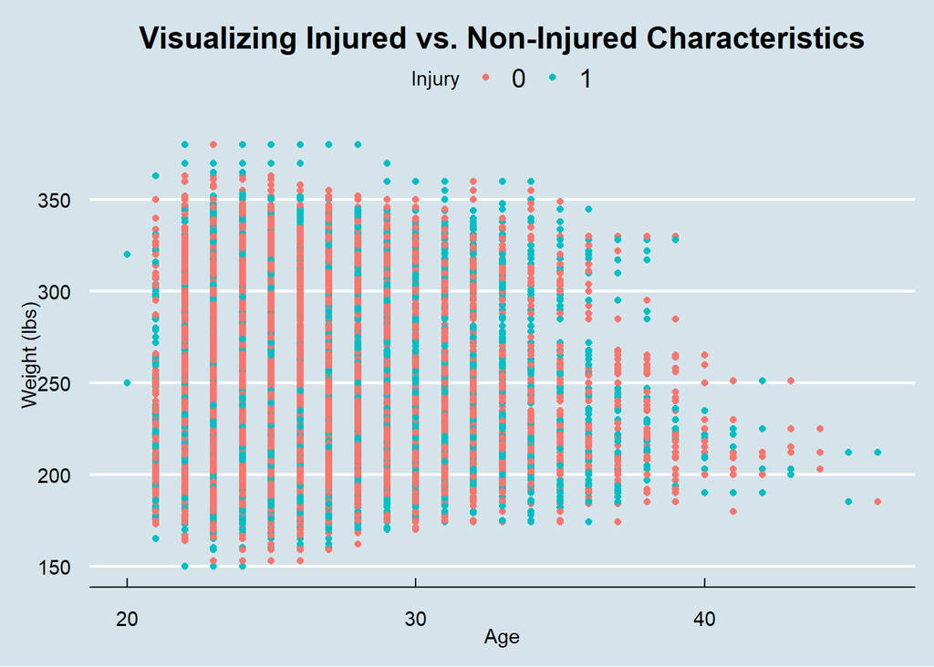

```r
# plots with 2 dimensions, color = injured vs. not injured to see "neighbors"
players %>%
  ggplot(aes(x = age, y = weight_pounds, color = injury)) +
  geom_point() +
  ggtitle("Visualizing Injured vs. Non-Injured Characteristics") +
  xlab("Age") +
  ylab("Weight (lbs)") +
  scale_color_discrete(name = "Injury")
```

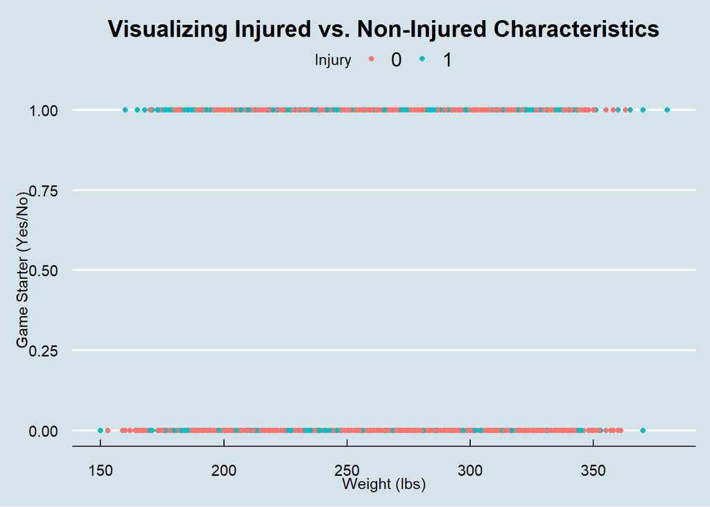

```r
players %>%
  ggplot(aes(x = weight_pounds, y = game_starter, color = injury)) +
  geom_point() +
  ggtitle("Visualizing Injured vs. Non-Injured Characteristics") +
  xlab("Weight (lbs)") +
  ylab("Game Starter (Yes/No)") +
  scale_color_discrete(name = "Injury")
```

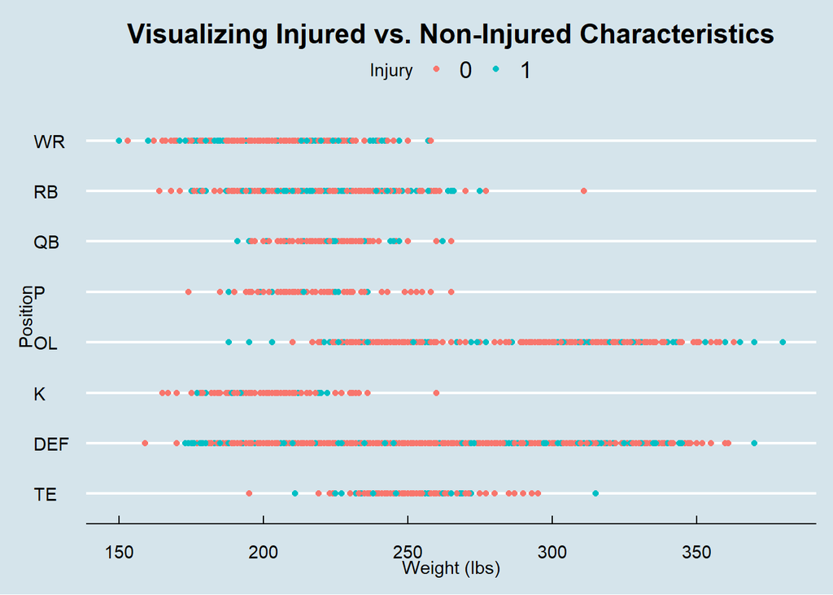

```r
players %>%
  ggplot(aes(x = weight_pounds, y = position_id, color = injury)) +
  geom_point() +
  ggtitle("Visualizing Injured vs. Non-Injured Characteristics") +
  xlab("Weight (lbs)") +
  ylab("Position") +
  scale_color_discrete(name = "Injury")
```

### Random Forest

```r
rf_fit = randomForest(injury ~ position_id + age + I(age^2) + game_starter + weight_pounds + year,
                      data = train_set) # fit random forest using training set

rf_fit
```

```
##
## Call:
##  randomForest(formula = injury ~ position_id + age + I(age^2) +      game_starter + weight_pounds + year, data = train_set)
##                Type of random forest: classification
##                      Number of trees: 500
## No. of variables tried at each split: 2
##
##         OOB estimate of  error rate: 36.2%
## Confusion matrix:
##      0    1 class.error
## 0 5824 3306       0.362
## 1 3441 6084       0.361
```

```r
p_hat_rf = predict(rf_fit, newdata = test_set, type = "prob")[,2] # get predicted probabilities

y_hat_rf = as.factor(ifelse(p_hat_rf > 0.5, 1, 0)) # use 0.5 cutoff to get estimates

confusionMatrix(data = y_hat_rf,
                reference = test_set[["injury"]], positive = "1") # generate confusion matrix
```

```
## Confusion Matrix and Statistics
##
##           Reference
## Prediction    0    1
##          0 2496 1483
##          1 1417 2599
##
##                Accuracy : 0.637
##                  95% CI : (0.627, 0.648)
##     No Information Rate : 0.511
##     P-Value [Acc > NIR] : <2e-16
##
##                   Kappa : 0.274
##
##  Mcnemar's Test P-Value : 0.227
##
##             Sensitivity : 0.637
##             Specificity : 0.638
##          Pos Pred Value : 0.647
##          Neg Pred Value : 0.627
##              Prevalence : 0.511
##          Detection Rate : 0.325
##    Detection Prevalence : 0.502
##       Balanced Accuracy : 0.637
##
##        'Positive' Class : 1
##
```

### Plot ROCs

[figure not shown]

```r
roc_logi = roc(test_set[["injury"]], p_hat_logit) # ROC curve creation
roc_knn = roc(test_set[["injury"]], f_hat_knn)
roc_rf = roc(test_set[["injury"]], p_hat_rf)

ggroc(list("Logistic Regression" = roc_logi, "kNN, k = 71" = roc_knn, "Random Forest" = roc_rf)) +
  theme(legend.title = element_blank()) +
  geom_segment(aes(x = 1, xend = 0, y = 0, yend = 1), color = "black", linetype = "dashed") +
  ggtitle("ROC Curves") +
  xlab("Specificity") +
  ylab("Sensitivity")
```

```r
auc(roc_logi) # calculate AUC for each ROC curve
```

```
## Area under the curve: 0.701
```

```r
auc(roc_knn)
```

```
## Area under the curve: 0.608
```

```r
auc(roc_rf)
```

```
## Area under the curve: 0.693
```

### So which model is the best?

Logistic regression has the highest accuracy.

Logistic regression has the highest AUC.

It’s clear that kNN is the poorest performing model, so we’ll consider logistic regression and random forest.

logistic regression:  
sensitivity: 0.675  
specificity: 0.600

The random forest is slightly more balanced in terms of sensitivity/specificity.

Logistic regression has the highest accuracy and the highest AUC of all 3 model. It also provides us with clearly interpretable odds ratios for the risk of injury. For these reasons, we’ll choose logistic regression as the best model.

make a table with all this information

```r
data.frame(Model = c("Logistic", "kNN (k = 21)", "Random Forest"),
                     Accuracy = c(0.638, 0.58, 0.637),
                     Sensitivity = c(0.675, 0.619, 0.637),
                     Specificity = c(0.600, 0.539, 0.638),
                     AUC = c(0.701, 0.608, 0.693)) %>%
  pander()
```

| Model | Accuracy | Sensitivity | Specificity | AUC |
| --- | --- | --- | --- | --- |
| Logistic | 0.638 | 0.675 | 0.6 | 0.701 |
| kNN (k = 21) | 0.58 | 0.619 | 0.539 | 0.608 |
| Random Forest | 0.637 | 0.637 | 0.638 | 0.693 |